# PERTEMUAN 2 Tugas kuliah

Naa’ila Nur Musyaffa

2026-08-30

# PEMANGGILAN PACKAGES

```r
library(dplyr)
library(readxl)
library(TTR)
library(forecast)
library(lmtest)
library(HoRM)
```

```r
library(orcutt)
library(ggplot2)
library(nortest)
```

# SOAL 1 (Market Share & Price)

## Impor Data

```r
data1 <- read_excel("C://Users//Na'aila//Downloads//Kuliah 2.xlsx", sheet = "Sheet1")
head(data1)
```

```
## # A tibble: 6 × 3
##   Period `Market Share` Price
##    <dbl>          <dbl> <dbl>
## 1      1           3.63  0.97
## 2      2           4.2   0.95
## 3      3           3.33  0.99
## 4      4           4.54  0.91
## 5      5           2.89  0.98
## 6      6           4.87  0.9
```

Data ini terdiri dari 3 peubah, yaitu period, market share dan price

## Eksplorasi Data

```r
View(data1)
str(data1)
```

```
## tibble [20 × 3] (S3: tbl_df/tbl/data.frame)
##  $ Period      : num [1:20] 1 2 3 4 5 6 7 8 9 10 ...
##  $ Market Share: num [1:20] 3.63 4.2 3.33 4.54 2.89 4.87 4.9 5.29 6.18 7.2 ...
##  $ Price       : num [1:20] 0.97 0.95 0.99 0.91 0.98 0.9 0.89 0.86 0.85 0.82 ...
```

```r
dim(data1)
```

```
## [1] 20  3
```

```r
summary(data1)
```

```
##      Period       Market Share       Price
##  Min.   : 1.00   Min.   :2.890   Min.   :0.7600
##  1st Qu.: 5.75   1st Qu.:4.787   1st Qu.:0.7900
##  Median :10.50   Median :6.490   Median :0.8300
##  Mean   :10.50   Mean   :6.215   Mean   :0.8520
##  3rd Qu.:15.25   3rd Qu.:7.982   3rd Qu.:0.9025
##  Max.   :20.00   Max.   :8.650   Max.   :0.9900
```

Data terdiri dari 20 pengamatan dengan tiga peubah, yaitu Period, Market Share, dan Price. Rata-rata Market Share sebesar 6,215, sedangkan rata-rata Price sebesar 0,852. Nilai Market Share berkisar antara 2,89–8,65, sementara Price berkisar antara 0,76–0,99.

### Scatter Plot

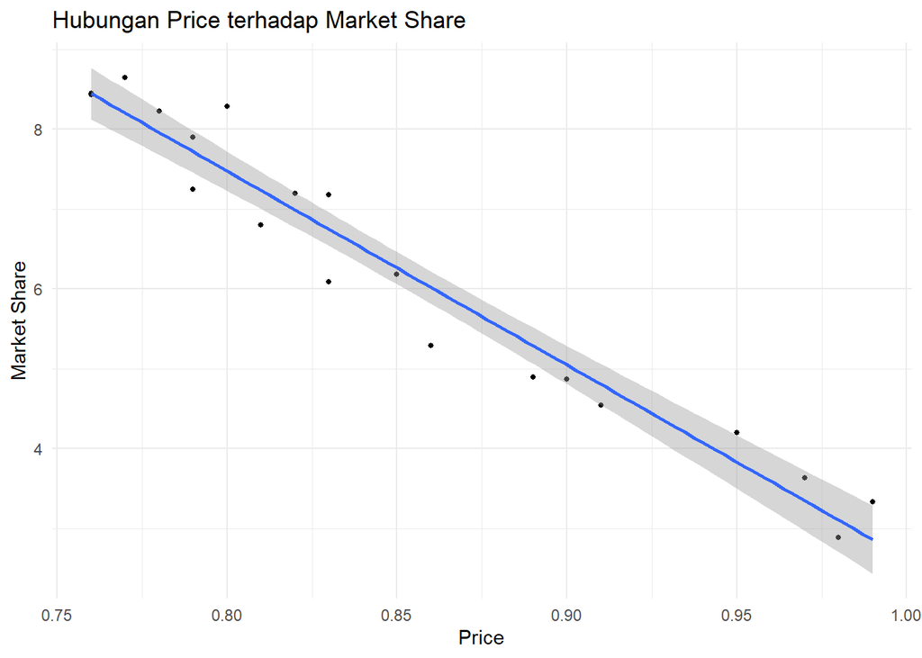

```r
ggplot(data1, aes(x = Price, y = `Market Share`)) +
  geom_point(size = 1) +
  geom_smooth(method = "lm", se = TRUE) +
  labs(
    title = "Hubungan Price terhadap Market Share",
    x = "Price",
    y = "Market Share"
  ) +
  theme_minimal()
```

Berdasarkan grafik hubungan Price terhadap Market Share, dapat dilihat adanya hubungan linear negatif antara kedua variabel. Hal ini ditunjukkan oleh garis regresi yang memiliki arah menurun. Hal ini berarti setiap peningkatan Price cenderung diikuti oleh penurunan Market Share. Sebaliknya, penurunan Price cenderung berkaitan dengan peningkatan Market Share. Namun, hubungan pada grafik ini menunjukkan kecenderungan dan belum dapat diartikan sebagai hubungan sebab akibat tanpa analisis lebih lanjut.

### Korelasi

```r
cor(data1$Price, data1$'Market Share')
```

```
## [1] -0.9752564
```

Berdasarkan hasil analisis korelasi, diperoleh nilai koefisien korelasi sebesar -0,9752564. Nilai tersebut menunjukkan adanya hubungan negatif yang sangat kuat antara Price dan Market Share. Artinya, semakin tinggi Price, maka Market Share cenderung semakin rendah, dan sebaliknya. Besarnya koefisien korelasi yang mendekati -1 menunjukkan bahwa hubungan linear antara kedua variabel sangat kuat.

## Pemodelan OLS

```r
model1 <- lm(`Market Share` ~ Price, data = data1)
summary(model1)
```

```
##
## Call:
## lm(formula = `Market Share` ~ Price, data = data1)
##
## Residuals:
##      Min       1Q   Median       3Q      Max
## -0.73068 -0.29764 -0.00966  0.30224  0.81193
##
## Coefficients:
##             Estimate Std. Error t value Pr(>|t|)
## (Intercept)   26.910      1.110   24.25 3.39e-15 ***
## Price        -24.290      1.298  -18.72 3.02e-13 ***
## ---
## Signif. codes:  0 '***' 0.001 '**' 0.01 '*' 0.05 '.' 0.1 ' ' 1
##
## Residual standard error: 0.4287 on 18 degrees of freedom
## Multiple R-squared:  0.9511, Adjusted R-squared:  0.9484
## F-statistic: 350.3 on 1 and 18 DF,  p-value: 3.019e-13
```

Dari hasil pemodelan OLS Data 1, diperoleh persamaan regresi:

$$\hat{Y}=26{,}910-24{,}290X$$

Nilai Price berpengaruh signifikan terhadap Market Share karena p-value 3,02 × 10⁻¹³ < 0,05. Koefisien Price yang negatif menunjukkan bahwa semakin tinggi Price, maka Market Share cenderung menurun. Nilai
$$R^2=0,9511$$
, artinya sekitar 95,11% variasi Market Share dapat dijelaskan oleh Price. ### Persamaan Regresi

```r
b0_1 <- coef(model1)[1]
b1_1 <- coef(model1)[2]

cat(
  "Market Share =",
  round(b0_1, 4),
  ifelse(b1_1 >= 0, " + ", " - "),
  round(abs(b1_1), 4),
  "Price"
)
```

```
## Market Share = 26.9099  -  24.2898 Price
```

Persamaan regresi yang diperoleh adalah:

$$\text{Market Share} = 26{,}9099 -
24{,}2898(\text{Price})$$

Interpretasinya, setiap kenaikan Price sebesar 1 satuan diperkirakan akan menurunkan Market Share sebesar 24,2898 satuan. Sementara itu, jika Price bernilai 0, maka Market Share diperkirakan sebesar 26,9099.

## Uji Asumsi

```r
# normalitas residual
shapiro.test(residuals(model1))
```

```
##
##  Shapiro-Wilk normality test
##
## data:  residuals(model1)
## W = 0.9744, p-value = 0.8437
```

Berdasarkan uji Shapiro-Wilk diperoleh p-value sebesar 0,8437 (> 0,05), sehingga dapat disimpulkan bahwa residual model berdistribusi normal.

```r
# homoskedastisitas
bptest(model1)
```

```
##
##  studentized Breusch-Pagan test
##
## data:  model1
## BP = 0.11646, df = 1, p-value = 0.7329
```

Berdasarkan uji Breusch-Pagan diperoleh p-value sebesar 0,7329 (> 0,05), sehingga tidak terdapat bukti adanya heteroskedastisitas pada model. Dengan demikian, asumsi homoskedastisitas terpenuhi.

## Pemeriksaan Autokorelasi

### Plot Residual terhadap Period

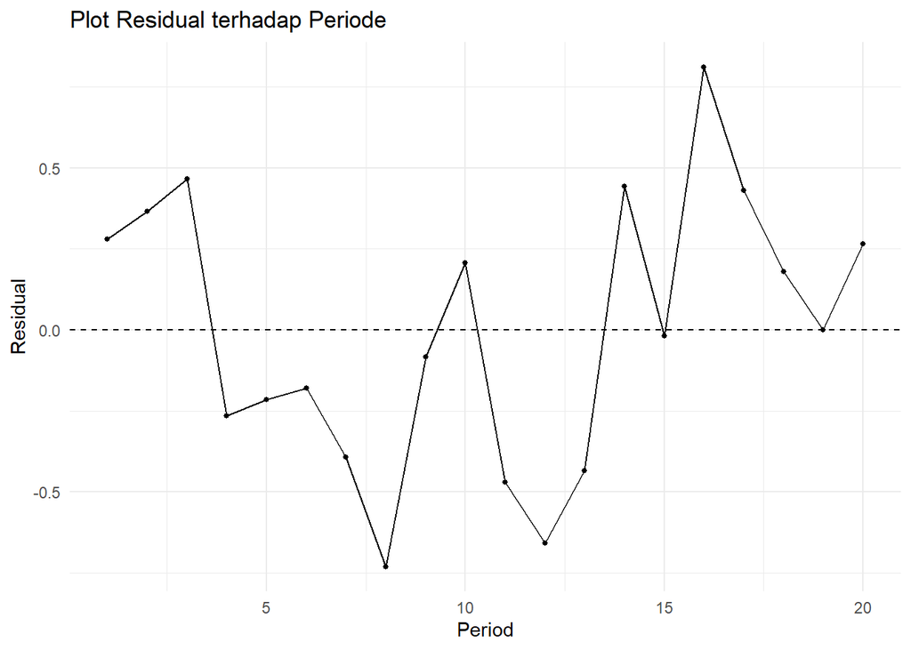

```r
resid1 <- data.frame(
  Periode = data1$Period,
  Residual = residuals(model1)
)
ggplot(resid1, aes(x = Periode, y = Residual)) +
  geom_line() +
  geom_point(size = 1)+
  geom_hline(
    yintercept = 0,
    linetype = "dashed"
  ) +
  labs(
    title = "Plot Residual terhadap Periode",
    x = "Period",
    y = "Residual"
  ) +
  theme_minimal()
```

### Uji Durbin-Watson

```r
dwtest(model1)
```

```
##
##  Durbin-Watson test
##
## data:  model1
## DW = 1.1358, p-value = 0.009813
## alternative hypothesis: true autocorrelation is greater than 0
```

Berdasarkan hasil uji Durbin-Watson, diperoleh nilai DW sebesar 1,1358 dengan p-value sebesar 0,009813. Karena p-value < 0,05, hasil pengujian menunjukkan bahwa terdapat autokorelasi positif yang signifikan pada residual model regresi.

## Penanganan Autokorelasi

Berdasarkan hasil uji Durbin-Watson hasil pengujian menunjukan bahwa terdapat autokorelasi positid yang signifikan pada residual model regresi oleh karena itu perlu dilakukan penanganan autokorelasi terhadap data 1

### Metode Cochrane-orcutt

```r
model1_co <- cochrane.orcutt(model1)
model1_co
```

```
## Cochrane-orcutt estimation for first order autocorrelation
##
## Call:
## lm(formula = `Market Share` ~ Price, data = data1)
##
##  number of interaction: 8
##  rho 0.425232
##
## Durbin-Watson statistic
## (original):    1.13582 , p-value: 9.813e-03
## (transformed): 1.95804 , p-value: 4.151e-01
##
##  coefficients:
## (Intercept)       Price
##    26.72209   -24.08413
```

```r
summary(model1_co)
```

```
## Call:
## lm(formula = `Market Share` ~ Price, data = data1)
##
##             Estimate Std. Error t value  Pr(>|t|)
## (Intercept)  26.7221     1.6329  16.365 7.713e-12 ***
## Price       -24.0841     1.9385 -12.424 5.903e-10 ***
## ---
## Signif. codes:  0 '***' 0.001 '**' 0.01 '*' 0.05 '.' 0.1 ' ' 1
##
## Residual standard error: 0.3955 on 17 degrees of freedom
## Multiple R-squared:  0.9008 ,  Adjusted R-squared:  0.895
## F-statistic: 154.4 on 1 and 17 DF,  p-value: < 5.903e-10
##
## Durbin-Watson statistic
## (original):    1.13582 , p-value: 9.813e-03
## (transformed): 1.95804 , p-value: 4.151e-01
```

```r
coef(model1_co)
```

```
## (Intercept)       Price
##    26.72209   -24.08413
```

Berdasarkan metode Cochrane-Orcutt, nilai ρ yang diperoleh sebesar 0,425232. Pada model awal, nilai DW sebesar 1,13582 dengan p-value 0,009813 < 0,05, sehingga masih terdapat autokorelasi. Setelah dilakukan transformasi, nilai DW menjadi 1,95804 dengan p-value 0,4151 > 0,05. Jadi, masalah autokorelasi sudah teratasi.

Model akhirnya adalah Market Share = 26,7221 − 24,0841 Price. Price berpengaruh signifikan terhadap Market Share karena p-value < 0,05. Nilai Adjusted R² = 0,895 berarti sekitar 89,5% variasi Market Share dapat dijelaskan oleh Price.

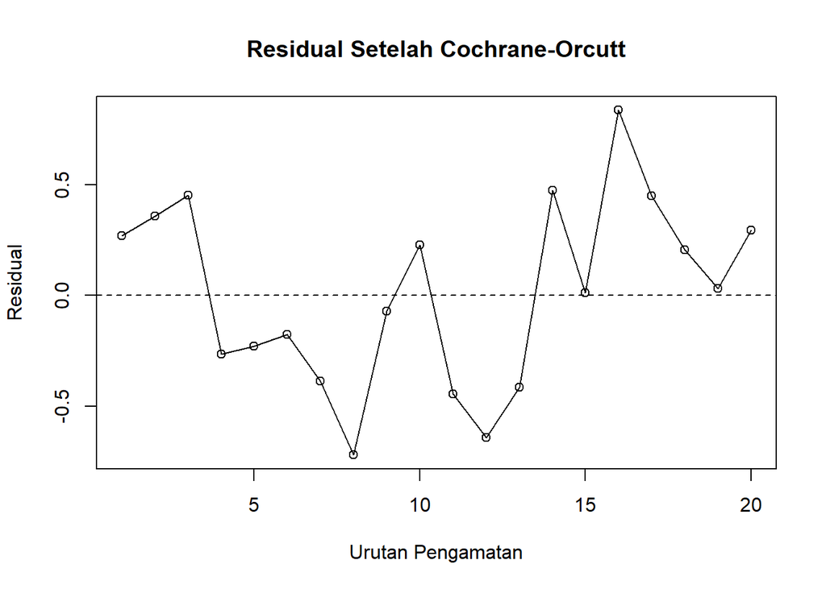

```r
resid1_co <- residuals(model1_co)

plot(
  resid1_co,
  type = "o",
  main = "Residual Setelah Cochrane-Orcutt",
  xlab = "Urutan Pengamatan",
  ylab = "Residual"
)
 abline(h=0, lty =2)
```

### Metode Hildreth-Lu

```r
# Menentukan nilai rho
rho <- seq(0.1, 0.99, by = 0.01)

hasil_hl <- data.frame(
  rho = rho,
  RSS = sapply(rho, function(r){
    y <- data1$`Market Share`
    x <- data1$Price

    y_trans <- y[-1] - r * y[-length(y)]
    x_trans <- x[-1] - r * x[-length(x)]

    model <- lm(y_trans ~ x_trans)

    sum(residuals(model)^2)
  })
)

hasil_hl
```

```
##     rho      RSS
## 1  0.10 2.979074
## 2  0.11 2.959328
## 3  0.12 2.940228
## 4  0.13 2.921770
## 5  0.14 2.903955
## 6  0.15 2.886782
## 7  0.16 2.870249
## 8  0.17 2.854355
## 9  0.18 2.839100
## 10 0.19 2.824481
## 11 0.20 2.810498
## 12 0.21 2.797148
## 13 0.22 2.784432
## 14 0.23 2.772345
```

[output cut: 76 more lines]

```r
rho_opt <- hasil_hl$rho[which.min(hasil_hl$RSS)]
rho_opt
```

```
## [1] 0.43
```

```r
# Model Hildreth-Lu
y <- data1$`Market Share`
x <- data1$Price

y_trans <- y[-1] - rho_opt * y[-length(y)]
x_trans <- x[-1] - rho_opt * x[-length(x)]

model1_hl <- lm(y_trans ~ x_trans)

summary(model1_hl)
```

```
##
## Call:
## lm(formula = y_trans ~ x_trans)
##
## Residuals:
##     Min      1Q  Median      3Q     Max
## -0.5532 -0.2512 -0.0552  0.2493  0.8302
##
## Coefficients:
##             Estimate Std. Error t value Pr(>|t|)
## (Intercept)  15.2246     0.9349   16.29 8.35e-12 ***
## x_trans     -24.0694     1.9474  -12.36 6.40e-10 ***
## ---
## Signif. codes:  0 '***' 0.001 '**' 0.01 '*' 0.05 '.' 0.1 ' ' 1
##
## Residual standard error: 0.3955 on 17 degrees of freedom
## Multiple R-squared:  0.8999, Adjusted R-squared:  0.894
## F-statistic: 152.8 on 1 and 17 DF,  p-value: 6.396e-10
```

```r
coef(model1_hl)
```

```
## (Intercept)     x_trans
##    15.22457   -24.06941
```

```r
dwtest(model1_hl)
```

```
##
##  Durbin-Watson test
##
## data:  model1_hl
## DW = 1.9656, p-value = 0.4228
## alternative hypothesis: true autocorrelation is greater than 0
```

Berdasarkan hasil metode Hildreth-Lu, diperoleh nilai
$$rho_{opt}=0{,}43$$
. Setelah dilakukan transformasi terhadap variabel Market Share dan Price, diperoleh model dengan koefisien:

$$Y^* = 15{,}2246 - 24{,}0694X^*$$

Price berpengaruh negatif terhadap Market Share. Artinya, setiap kenaikan 1 satuan Price akan menurunkan Market Share sebesar sekitar 24,0694 satuan, dengan variabel lain dianggap tetap.

Nilai
$$R^2=0{,}8999$$
menunjukkan bahwa sekitar 89,99% variasi Market Share dapat dijelaskan oleh Price setelah dilakukan penanganan autokorelasi dengan metode Hildreth-Lu. Selain itu, nilai p-value untuk koefisien Price sebesar
$$6,40\times10^{-10}<0,05$$
, sehingga Price berpengaruh signifikan terhadap Market Share.

Untuk hasil Durbin-Watson, diperoleh
$$DW=1{,}9656$$
dengan p-value 0,4228 > 0,05, sehingga tidak terdapat bukti adanya autokorelasi positif pada residual. Jadi, metode Hildreth-Lu berhasil menangani masalah autokorelasi pada model.

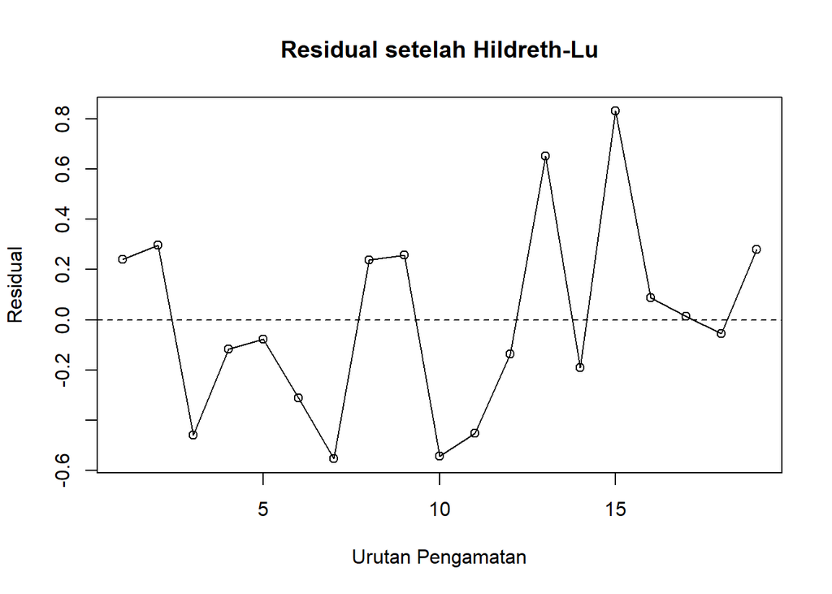

```r
# Plot residual Hilderth-Lu
resid21_hl <- residuals(model1_hl)

plot(
  resid21_hl,
  type = "o",
  main = "Residual setelah Hildreth-Lu",
  xlab = "Urutan Pengamatan",
  ylab = "Residual"

)
abline(h=0, lty=2)
```

Berdasarkan grafik residual setelah transformasi Hildreth-Lu, residual cenderung menyebar secara acak di sekitar nilai nol tanpa pola sistematis. Dengan nilai ρ optimal sebesar 0,43, diperoleh statistik Durbin-Watson sebesar 1,9656 dengan p-value 0,4228 (> 0,05). Dengan demikian, H₀ tidak ditolak, sehingga dapat disimpulkan bahwa tidak terdapat autokorelasi pada residual model setelah dilakukan transformasi Hildreth-Lu. Hal ini menunjukkan bahwa transformasi Hildreth-Lu efektif dalam mengatasi permasalahan autokorelasi pada model regresi.

## Perbandingan Cochrane-Orcutt dan Hilderth-Lu

```r
# Parameter Rho

cat(
  "Rho Cochrane-Orcutt:",
  round(model1_co$rho, 4),
  "\n"
)
```

```
## Rho Cochrane-Orcutt: 0.4252
```

```r
cat(
  "Rho Hildreth-Lu:",
  round(rho_opt, 4)
)
```

```
## Rho Hildreth-Lu: 0.43
```

```r
# Perbandingan RSS
rss_ols1 <- sum(residuals(model1)^2)
rss_co1 <- sum(residuals(model1_co)^2)
rss_hl1 <- sum(residuals(model1_hl)^2)

data.frame(
  Metode = c(
    "OLS",
    "Cochrane-Orcutt",
    "Hildreth-Lu"
  ),
  RSS = c(
    rss_ols1,
    rss_co1,
    rss_hl1
  )
)
```

```
##            Metode      RSS
## 1             OLS 3.308257
## 2 Cochrane-Orcutt 3.316041
## 3     Hildreth-Lu 2.659433
```

```r
# Perbandingan Durbin-Watson
dw_ols1 <- dwtest(model1)
dw_co1 <- dwtest(model1_co)
dw_hl1 <- dwtest(model1_hl)
data.frame(
  Metode = c(
    "OLS",
    "Cochrane-Orcutt",
    "Hildreth-Lu"
  ),
  DW = c(
    dw_ols1$statistic,
    dw_co1$statistic,
    dw_hl1$statistic
  ),
  P_Value = c(
    dw_ols1$p.value,
    dw_co1$p.value,
    dw_hl1$p.value
  )
)
```

```
##            Metode       DW     P_Value
## 1             OLS 1.135816 0.009813346
## 2 Cochrane-Orcutt 1.958041 0.415141765
## 3     Hildreth-Lu 1.965564 0.422831364
```

Berdasarkan perbandingan nilai rho , RSS, dan Durbin-Watson, metode Cochrane-Orcutt dan Hildreth-Lu sama-sama mampu menangani masalah autokorelasi pada model. Nilai rho kedua metode relatif sama, yaitu 0,4252 pada Cochrane-Orcutt dan 0,43 pada Hildreth-Lu. Dari nilai RSS, Hildreth-Lu menghasilkan RSS paling kecil, yaitu 2,659433, dibandingkan Cochrane-Orcutt sebesar 3,316041 dan OLS sebesar 3,308257. Berdasarkan uji Durbin-Watson, OLS masih mengalami autokorelasi karena p-value 0,009813 < 0,05, sedangkan Cochrane-Orcutt dan Hildreth-Lu memiliki p-value masing-masing 0,415142 dan 0,422831 sehingga tidak terdapat bukti autokorelasi. Dengan mempertimbangkan ketiga ukuran tersebut, metode Hildreth-Lu dipilih sebagai metode yang lebih baik untuk menangani autokorelasi pada data ini, karena memiliki RSS paling kecil dan nilai DW paling dekat dengan 2.

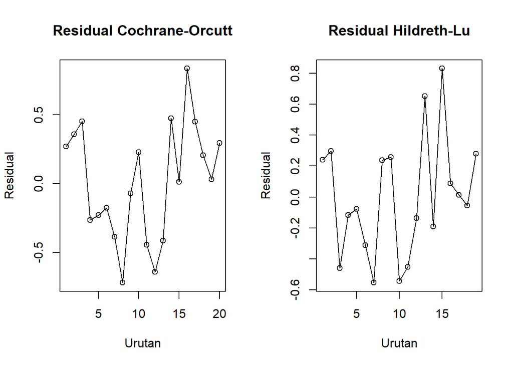

```r
# Perbandingan Residual
par(mfrow = c(1, 2))

plot(
  residuals(model1_co),
  type = "o",
  main = "Residual Cochrane-Orcutt",
  xlab = "Urutan",
  ylab = "Residual"
)

plot(
  residuals(model1_hl),
  type = "o",
  main = "Residual Hildreth-Lu",
  xlab = "Urutan",
  ylab = "Residual"
)
```

```r
par(mfrow = c(1,1))
```

Berdasarkan plot residual, residual Cochrane-Orcutt dan Hildreth-Lu sama-sama berfluktuasi di sekitar nilai nol. Pada residual Cochrane-Orcutt masih terlihat pola tertentu, terutama kecenderungan residual meningkat pada beberapa pengamatan akhir. Sementara itu, residual Hildreth-Lu terlihat lebih menyebar di sekitar nol dan tidak menunjukkan pola yang terlalu jelas. Hal ini menunjukkan bahwa setelah dilakukan penanganan autokorelasi, residual Hildreth-Lu cenderung lebih acak dibandingkan Cochrane-Orcutt sehingga model Hildreth-Lu memberikan hasil yang lebih baik.

# SOAL 2 (Sales & Adversiting)

## Impor Data

```r
data2 <- read_excel("C://Users//Na'aila//Downloads//Kuliah 2.xlsx", sheet = "Sheet2")
head(data2)
```

```
## # A tibble: 6 × 3
##    Year Sales Advertising
##   <dbl> <dbl>       <dbl>
## 1  1975  11.7         9.4
## 2  1976  12           9.6
## 3  1977  12.3        10
## 4  1978  12.8        10.4
## 5  1979  13.1        10.8
## 6  1980  13.6        10.9
```

## Eksplorasi Data

```r
View(data2)
str(data2)
```

```
## tibble [40 × 3] (S3: tbl_df/tbl/data.frame)
##  $ Year       : num [1:40] 1975 1976 1977 1978 1979 ...
##  $ Sales      : num [1:40] 11.7 12 12.3 12.8 13.1 13.6 13.9 14.4 14.7 15.3 ...
##  $ Advertising: num [1:40] 9.4 9.6 10 10.4 10.8 10.9 11.7 12.2 12.5 12.9 ...
```

```r
dim(data2)
```

```
## [1] 40  3
```

```r
summary(data2)
```

```
##       Year          Sales        Advertising
##  Min.   :1975   Min.   :11.70   Min.   : 9.40
##  1st Qu.:1985   1st Qu.:15.45   1st Qu.:12.97
##  Median :1994   Median :17.90   Median :15.90
##  Mean   :1994   Mean   :17.13   Mean   :15.73
##  3rd Qu.:2004   3rd Qu.:19.30   3rd Qu.:18.55
##  Max.   :2014   Max.   :21.00   Max.   :22.10
```

Berdasarkan hasil eksplorasi data, terdapat 40 observasi yang mencakup periode tahun 1975–2014. Variabel Sales memiliki nilai minimum sebesar 11,70, maksimum 21,00, dan rata-rata 17,13. Sementara itu, variabel Advertising memiliki nilai minimum 9,40, maksimum 22,10, dan rata-rata 15,73. Nilai tersebut menunjukkan bahwa Sales dan Advertising memiliki variasi selama periode pengamatan. Selanjutnya, hubungan antara Advertising sebagai variabel independen dan Sales sebagai variabel dependen dapat dianalisis menggunakan scatter plot dan pemodelan regresi linear.

### Scatter Plot

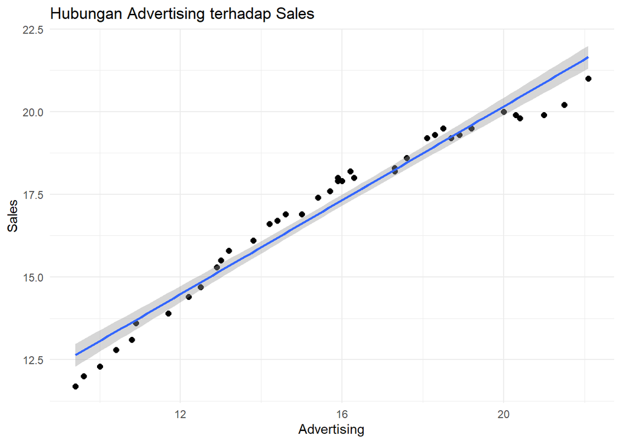

```r
ggplot(data2, aes(x = Advertising, y = Sales)) +
  geom_point(size = 2) +
  geom_smooth(method = "lm", se = TRUE) +
  labs(
    title = "Hubungan Advertising terhadap Sales",
    x = "Advertising",
    y = "Sales"
  ) +
  theme_minimal()
```

Berdasarkan scatter plot, terdapat hubungan linear positif yang kuat antara Advertising dan Sales. Dengan demikian, semakin besar pengeluaran untuk Advertising, secara umum semakin besar pula Sales yang diperoleh. Pola ini menunjukkan bahwa variabel Advertising berpotensi menjadi salah satu faktor yang dapat digunakan untuk memprediksi Sales melalui model regresi linear (OLS).

### Korelasi

```r
cor(data2$Advertising, data2$Sales)
```

```
## [1] 0.9797631
```

## Pemodelan OLS

```r
model2 <- lm(Sales ~ Advertising, data = data2)

summary(model2)
```

```
##
## Call:
## lm(formula = Sales ~ Advertising, data = data2)
##
## Residuals:
##      Min       1Q   Median       3Q      Max
## -1.02398 -0.39609  0.00937  0.46522  0.74938
##
## Coefficients:
##             Estimate Std. Error t value Pr(>|t|)
## (Intercept)  5.96911    0.37907   15.75   <2e-16 ***
## Advertising  0.70953    0.02351   30.17   <2e-16 ***
## ---
## Signif. codes:  0 '***' 0.001 '**' 0.01 '*' 0.05 '.' 0.1 ' ' 1
##
## Residual standard error: 0.5247 on 38 degrees of freedom
## Multiple R-squared:  0.9599, Adjusted R-squared:  0.9589
## F-statistic: 910.5 on 1 and 38 DF,  p-value: < 2.2e-16
```

Hasil analisis menunjukkan bahwa Advertising memiliki hubungan positif dan sangat kuat terhadap Sales, dengan nilai korelasi sebesar 0,9798. Model regresi menunjukkan bahwa setiap peningkatan 1 unit Advertising dapat meningkatkan Sales sebesar 0,70953 unit. Pengaruh tersebut signifikan secara statistik (p-value < 0,05). Selain itu, nilai R² sebesar 95,99% menunjukkan bahwa model mampu menjelaskan sebagian besar variasi Sales. Dengan demikian, model OLS dapat dikatakan memiliki kemampuan penjelasan yang sangat baik untuk hubungan Advertising terhadap Sales.

### Persamaan Regresi

```r
b0_2 <- coef(model2)[1]
b1_2 <- coef(model2)[2]

cat(
  "Sales =",
  round(b0_2, 4),
  ifelse(b1_2 >= 0, " + ", " - "),
  round(abs(b1_2), 4),
  "Advertising"
)
```

```
## Sales = 5.9691  +  0.7095 Advertising
```

Persamaan regresi yang diperoleh adalah:

$$\text{Sales} = 5{,}9691 + 0{,}7095
(\text{Advertising})$$
## Uji Asumsi

```r
# normalitas residual
shapiro.test(residuals(model2))
```

```
##
##  Shapiro-Wilk normality test
##
## data:  residuals(model2)
## W = 0.93744, p-value = 0.02837
```

Berdasarkan uji Shapiro-Wilk diperoleh p-value sebesar 0,02837 < 0,05, sehingga H₀ ditolak. Dengan demikian, residual model tidak berdistribusi normal.

```r
# homoskedastisitas
bptest(model2)
```

```
##
##  studentized Breusch-Pagan test
##
## data:  model2
## BP = 0.0017543, df = 1, p-value = 0.9666
```

Berdasarkan uji Breusch-Pagan diperoleh p-value sebesar 0,9666 > 0,05, sehingga H₀ tidak ditolak. Dengan demikian, tidak terdapat indikasi heteroskedastisitas pada model regresi.

## Pemeriksaan Autokorelasi

### Plot Residual terhadap Year

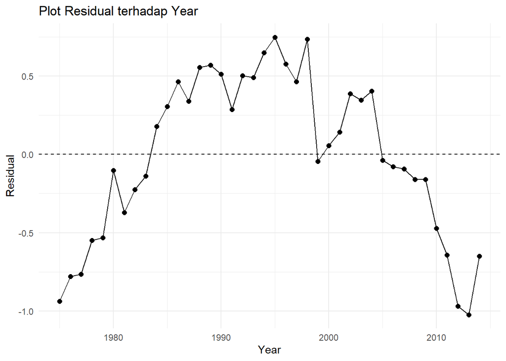

```r
resid2 <- data.frame(
  Year = data2$Year,
  Residual = residuals(model2)
)

ggplot(resid2, aes(x = Year, y = Residual)) +
  geom_line() +
  geom_point(size = 2) +
  geom_hline(
    yintercept = 0,
    linetype = "dashed"
  ) +
  labs(
    title = "Plot Residual terhadap Year",
    x = "Year",
    y = "Residual"
  ) +
  theme_minimal()
```

Berdasarkan plot residual terhadap tahun, terlihat bahwa residual tidak tersebar secara acak di sekitar garis nol. Residual cenderung membentuk pola tertentu berdasarkan waktu, yaitu pada awal periode sebagian besar residual bernilai negatif, kemudian didominasi nilai positif, dan pada akhir periode kembali cenderung negatif. Pola tersebut mengindikasikan adanya kemungkinan autokorelasi pada residual. Oleh karena itu, perlu dilakukan pengujian lebih lanjut menggunakan uji Durbin-Watson.

### Uji Durbin-Watson

```r
dw2 <- dwtest(model2)

dw2
```

```
##
##  Durbin-Watson test
##
## data:  model2
## DW = 0.19905, p-value < 2.2e-16
## alternative hypothesis: true autocorrelation is greater than 0
```

Berdasarkan uji Durbin-Watson diperoleh nilai statistik DW sebesar 0,19905 dengan p-value < 2,2 × 10⁻¹⁶. Karena p-value < 0,05, maka H₀ ditolak. Dengan demikian, terdapat autokorelasi positif pada residual model regresi.

## Penanganan Autokorelasi

### Metode Cochrane-Orcutt

```r
model2_co <- cochrane.orcutt(model2)

model2_co
```

```
## Cochrane-orcutt estimation for first order autocorrelation
##
## Call:
## lm(formula = Sales ~ Advertising, data = data2)
##
##  number of interaction: 64
##  rho 0.926479
##
## Durbin-Watson statistic
## (original):    0.19905 , p-value: 7.886e-18
## (transformed): 1.94843 , p-value: 4.091e-01
##
##  coefficients:
## (Intercept) Advertising
##   12.529507    0.387315
```

Berdasarkan metode Cochrane–Orcutt, diperoleh nilai rho sebesar 0,926479. Sebelum transformasi, nilai Durbin-Watson sebesar 0,19905 dengan p-value 7,886 × 10⁻¹⁸ yang menunjukkan adanya autokorelasi positif. Setelah dilakukan transformasi Cochrane–Orcutt, nilai Durbin-Watson meningkat menjadi 1,94843 dengan p-value 0,4091. Karena p-value > 0,05, maka H₀ tidak ditolak, sehingga dapat disimpulkan bahwa autokorelasi telah berhasil diatasi.

```r
summary(model2_co)
```

```
## Call:
## lm(formula = Sales ~ Advertising, data = data2)
##
##              Estimate Std. Error t value  Pr(>|t|)
## (Intercept) 12.529507   1.834574   6.830 4.786e-08 ***
## Advertising  0.387315   0.089196   4.342 0.0001052 ***
## ---
## Signif. codes:  0 '***' 0.001 '**' 0.01 '*' 0.05 '.' 0.1 ' ' 1
##
## Residual standard error: 0.1972 on 37 degrees of freedom
## Multiple R-squared:  0.3376 ,  Adjusted R-squared:  0.3197
## F-statistic: 18.9 on 1 and 37 DF,  p-value: < 1.052e-04
##
## Durbin-Watson statistic
## (original):    0.19905 , p-value: 7.886e-18
## (transformed): 1.94843 , p-value: 4.091e-01
```

Hasil estimasi Cochrane–Orcutt menghasilkan persamaan
$$\hat{Y}{Sales}=12,529507+0,387315Advertising$$
. Variabel Advertising berpengaruh positif dan signifikan terhadap Sales dengan p-value sebesar 0,0001052. Model secara keseluruhan juga signifikan dengan p-value < 0,05 dan memiliki R² sebesar 0,3376. Selain itu, setelah transformasi Cochrane–Orcutt diperoleh nilai Durbin-Watson sebesar 1,94843 dengan p-value 0,4091 > 0,05, sehingga dapat disimpulkan bahwa masalah autokorelasi pada model telah berhasil diatasi.

```r
coef(model2_co)
```

```
## (Intercept) Advertising
##  12.5295074   0.3873155
```

Nilai Multiple R-squared sebesar 0,3376 menunjukkan bahwa sebesar 33,76% variasi Sales dapat dijelaskan oleh variabel Advertising dalam model. Sementara itu, sebesar 66,24% variasi Sales dijelaskan oleh faktor lain yang tidak dimasukkan dalam model. Nilai Adjusted R-squared sebesar 0,3197 menunjukkan kemampuan penjelasan model setelah disesuaikan dengan jumlah variabel yang digunakan.

```r
dwtest(model2_co)
```

```
##
##  Durbin-Watson test
##
## data:  model2_co
## DW = 1.9484, p-value = 0.4091
## alternative hypothesis: true autocorrelation is greater than 0
```

Berdasarkan uji Durbin-Watson setelah transformasi Cochrane–Orcutt, diperoleh nilai DW sebesar 1,9484 dengan p-value sebesar 0,4091. Karena p-value lebih besar dari 0,05, maka H₀ tidak ditolak. Dengan demikian, dapat disimpulkan bahwa tidak terdapat autokorelasi positif pada residual setelah dilakukan metode Cochrane–Orcutt, sehingga masalah autokorelasi pada model awal telah berhasil diatasi.

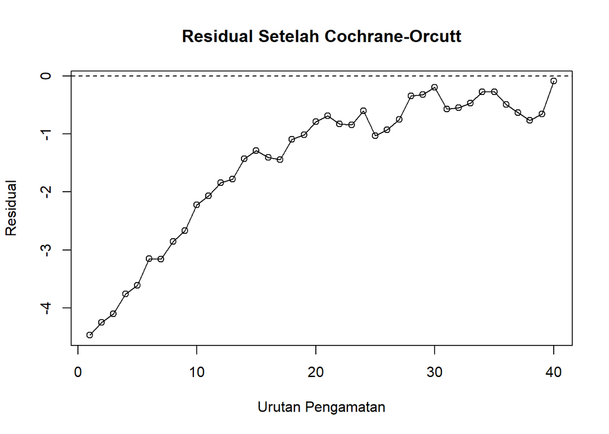

```r
resid2_co <- residuals(model2_co)

plot(
  resid2_co,
  type = "o",
  main = "Residual Setelah Cochrane-Orcutt",
  xlab = "Urutan Pengamatan",
  ylab = "Residual"
)

abline(h = 0, lty = 2)
```

Berdasarkan grafik residual setelah Cochrane–Orcutt, residual masih menunjukkan pola tertentu dan sebagian besar berada di bawah garis nol. Namun, keputusan mengenai ada atau tidaknya autokorelasi tidak hanya didasarkan pada pola grafik, melainkan juga pada hasil uji Durbin-Watson. Hasil uji menunjukkan p-value sebesar 0,4091 > 0,05, sehingga secara statistik tidak terdapat bukti adanya autokorelasi positif setelah transformasi.

### Metode Hildreth-Lu

```r
rho <- seq(0.1, 0.99, by = 0.01)

hasil_hl2 <- data.frame(
  rho = rho,
  RSS = sapply(rho, function(r) {

    y <- data2$Sales
    x <- data2$Advertising

    y_trans <- y[-1] - r * y[-length(y)]
    x_trans <- x[-1] - r * x[-length(x)]

    model <- lm(y_trans ~ x_trans)

    sum(residuals(model)^2)
  })
)

hasil_hl2
```

```
##     rho      RSS
## 1  0.10 7.813168
## 2  0.11 7.657585
## 3  0.12 7.503988
## 4  0.13 7.352378
## 5  0.14 7.202754
## 6  0.15 7.055115
## 7  0.16 6.909461
## 8  0.17 6.765791
## 9  0.18 6.624106
## 10 0.19 6.484403
## 11 0.20 6.346684
## 12 0.21 6.210947
## 13 0.22 6.077191
## 14 0.23 5.945417
```

[output cut: 76 more lines]

```r
rho_opt2 <- hasil_hl2$rho[which.min(hasil_hl2$RSS)]

rho_opt2
```

```
## [1] 0.93
```

```r
# Model Hilderth-Lu
y <- data2$Sales
x <- data2$Advertising

y_trans <- y[-1] - rho_opt2 * y[-length(y)]
x_trans <- x[-1] - rho_opt2 * x[-length(x)]

model2_hl <- lm(y_trans ~ x_trans)

summary(model2_hl)
```

```
##
## Call:
## lm(formula = y_trans ~ x_trans)
##
## Residuals:
##      Min       1Q   Median       3Q      Max
## -0.46653 -0.13021  0.00151  0.10484  0.52230
##
## Coefficients:
##             Estimate Std. Error t value Pr(>|t|)
## (Intercept)  0.89485    0.13305   6.726 6.59e-08 ***
## x_trans      0.37855    0.09132   4.145  0.00019 ***
## ---
## Signif. codes:  0 '***' 0.001 '**' 0.01 '*' 0.05 '.' 0.1 ' ' 1
##
## Residual standard error: 0.1973 on 37 degrees of freedom
## Multiple R-squared:  0.3171, Adjusted R-squared:  0.2987
## F-statistic: 17.18 on 1 and 37 DF,  p-value: 0.0001896
```

```r
coef(model2_hl)
```

```
## (Intercept)     x_trans
##   0.8948494   0.3785509
```

```r
dwtest(model2_hl)
```

```
##
##  Durbin-Watson test
##
## data:  model2_hl
## DW = 1.9381, p-value = 0.3985
## alternative hypothesis: true autocorrelation is greater than 0
```

Berdasarkan hasil metode Hildreth-Lu, diperoleh nilai ρ optimum sebesar 0,93, yang menunjukkan adanya korelasi positif yang cukup kuat antar residual. Setelah dilakukan transformasi dengan nilai tersebut, diperoleh model dengan koefisien intersep sebesar 0,8948 dan koefisien `x_trans` sebesar 0,3786. Nilai p-value untuk `x_trans` sebesar 0,0001896 (< 0,05), sehingga variabel Advertising berpengaruh signifikan terhadap Sales pada model yang telah ditransformasi.

Nilai R² sebesar 0,3171 menunjukkan bahwa sekitar 31,71% variasi Sales dapat dijelaskan oleh Advertising setelah penanganan autokorelasi dengan metode Hildreth-Lu, sedangkan sisanya dijelaskan oleh faktor lain di luar model. Hasil uji Durbin-Watson sebesar 1,9381 dengan p-value 0,3985 (> 0,05) menunjukkan bahwa tidak terdapat autokorelasi positif yang signifikan pada residual setelah dilakukan metode Hildreth-Lu. Jadi, metode Hildreth-Lu berhasil memperbaiki masalah autokorelasi pada model.

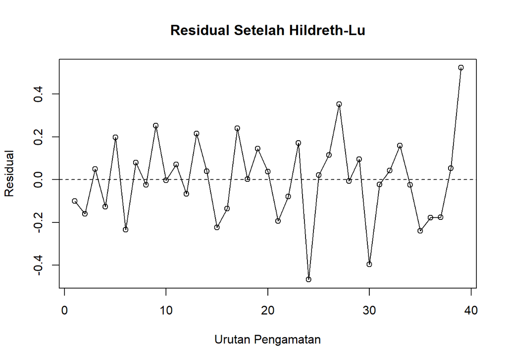

```r
# Plot residual Hilderth-Lu
resid2_hl <- residuals(model2_hl)

plot(
  resid2_hl,
  type = "o",
  main = "Residual Setelah Hildreth-Lu",
  xlab = "Urutan Pengamatan",
  ylab = "Residual"
)

abline(h = 0, lty = 2)
```

Berdasarkan plot residual setelah dilakukan metode Hildreth-Lu, residual terlihat menyebar di sekitar garis nol dan tidak membentuk pola tertentu. Nilai residual juga berada di atas dan di bawah garis nol secara bergantian. Hal ini menunjukkan bahwa setelah dilakukan transformasi Hildreth-Lu, pola autokorelasi pada residual sudah berkurang sehingga residual cenderung lebih acak. Hasil ini juga sejalan dengan uji Durbin-Watson sebelumnya yang menunjukkan nilai DW = 1,9381 dengan p-value = 0,3985 > 0,05, sehingga tidak terdapat autokorelasi positif yang signifikan pada residual.

## Perbandingan Cochrane-Orcutt dan Hilderth-Lu

```r
# Perbandingan Nilai Rho
cat(
  "Rho Cochrane-Orcutt:",
  round(model2_co$rho, 4),
  "\n"
)
```

```
## Rho Cochrane-Orcutt: 0.9265
```

```r
cat(
  "Rho Hildreth-Lu:",
  round(rho_opt2, 4)
)
```

```
## Rho Hildreth-Lu: 0.93
```

```r
# Perbandingan RSS
rss_ols2 <- sum(residuals(model2)^2)
rss_co2 <- sum(residuals(model2_co)^2)
rss_hl2 <- sum(residuals(model2_hl)^2)

data.frame(
  Metode = c(
    "OLS",
    "Cochrane-Orcutt",
    "Hildreth-Lu"
  ),
  RSS = c(
    rss_ols2,
    rss_co2,
    rss_hl2
  )
)
```

```
##            Metode        RSS
## 1             OLS  10.463344
## 2 Cochrane-Orcutt 151.204875
## 3     Hildreth-Lu   1.439922
```

```r
# Perbandingan Durbin-Watson
dw_ols2 <- dwtest(model2)
dw_co2 <- dwtest(model2_co)

dw_hl2 <- dwtest(model2_hl)

data.frame(
  Metode = c(
    "OLS",
    "Cochrane-Orcutt",
    "Hildreth-Lu"
  ),
  DW = c(
    dw_ols2$statistic,
    dw_co2$statistic,
    dw_hl2$statistic
  ),
  P_Value = c(
    dw_ols2$p.value,
    dw_co2$p.value,
    dw_hl2$p.value
  )
)
```

```
##            Metode        DW      P_Value
## 1             OLS 0.1990516 7.886071e-18
## 2 Cochrane-Orcutt 1.9484292 4.090616e-01
## 3     Hildreth-Lu 1.9380707 3.984612e-01
```

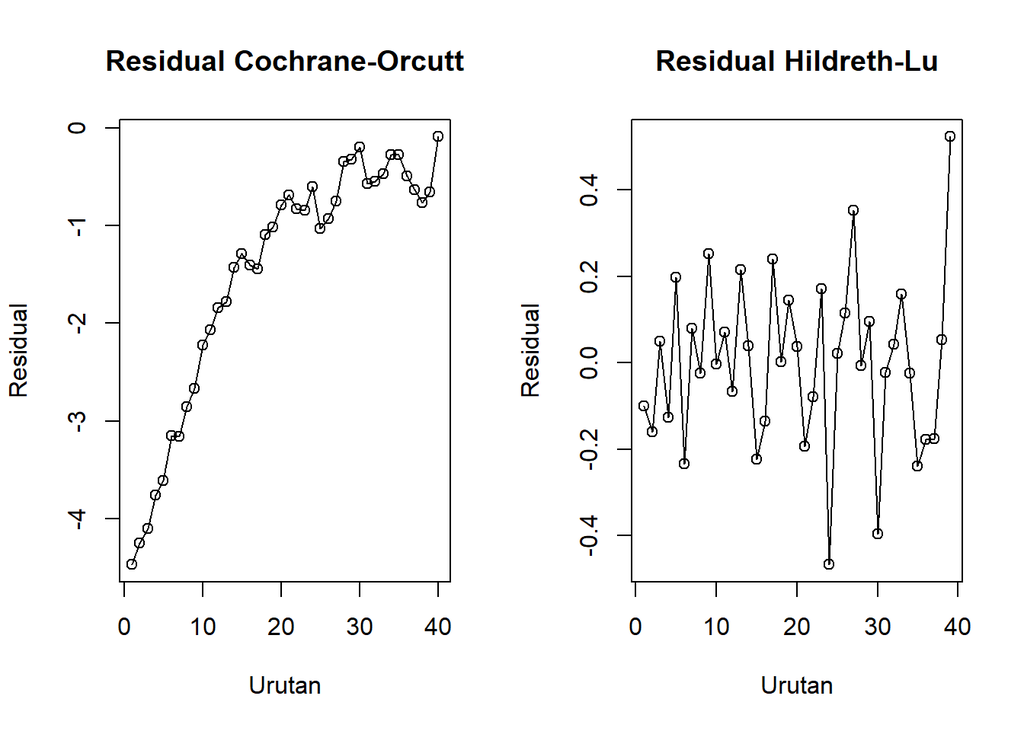

```r
# Perbandingan Residual
par(mfrow = c(1, 2))

plot(
  residuals(model2_co),
  type = "o",
  main = "Residual Cochrane-Orcutt",
  xlab = "Urutan",
  ylab = "Residual"
)

plot(
  residuals(model2_hl),
  type = "o",
  main = "Residual Hildreth-Lu",
  xlab = "Urutan",
  ylab = "Residual"
)
```

```r
par(mfrow = c(1, 1))
```

Berdasarkan hasil perbandingan, nilai rho Cochrane-Orcutt sebesar 0,9265 dan Hildreth-Lu sebesar 0,93, sehingga keduanya memberikan nilai rho yang hampir sama. Dari nilai RSS, metode Hildreth-Lu memiliki RSS yang lebih kecil, yaitu 1,439922, dibandingkan Cochrane-Orcutt sebesar 151,204875 dan OLS sebesar 10,463334, sehingga Hildreth-Lu menghasilkan residual yang lebih kecil. Selain itu, berdasarkan uji Durbin-Watson, nilai DW OLS sebesar 0,1991 dengan p-value < 0,05 menunjukkan adanya autokorelasi. Setelah dilakukan perbaikan, nilai DW Cochrane-Orcutt menjadi 1,9484 dengan p-value 0,4091, sedangkan Hildreth-Lu sebesar 1,9381 dengan p-value 0,3985. Keduanya memiliki p-value > 0,05, sehingga tidak terdapat bukti adanya autokorelasi setelah perbaikan. Dengan demikian, Hildreth-Lu lebih baik digunakan karena menghasilkan RSS paling kecil, sementara nilai DW-nya juga sudah menunjukkan tidak adanya autokorelasi.